# TP I : Introduction à la statistique descriptive

# Introduction

Ce premier TP a pour but de vous familiariser avec les outils de bases de statistiques descriptives. L’idée est d’appliquer les différentes notions vues jusqu’à présent sur des bases de données diverses (quantitatives, qualitatives, discrètes, continues) en de réaliser d’autres analyses statistiques par la suite.

# Résumer des exercices vus en cours

Dans cette section il vous est demandé de reporter les différents exercices vus pendant le cours, pour que vous ayez une trace informatique de ce que vous avez fait.

Exercice 1: Quel est le type de ces variables ? Âge d’un individu: Quantitative exemple:(1 an , 2ans …100 ans) Gentillesse d’un individu: soit qualitative : ordinale (oui ou non) soit quantitative par pourcentage pour chaque individue Température d’un local: qualitative ordinale (chaud, froid) ou bien quantitative continue (degré en celsius par exemple) Prix du pain: quantitative (50 centimes, 60 centimes)ou bien qualitative (prix bas/ prix elevé) Couleur des yeux de votre voisin: qualitative (categoriale (couleur bleu noir vert …)) Puissance d’un son soit qualitative (ordinale fort ou bas) soit quantitative (le calculer en decibel) Intelligence d’une personne(quantitative (exemple le taux d’intelligence par QI)) qualitative (oui ou non) Situation d’un appartement dans votre immeuble qualitative (ordinale exemple: etage 1 ou 2 ou rez de chaussée ou bien grande petite) Situation socio-professionnelle de votre oncle: qualitative (ordinale chomeur / employé ) Compréhension de cette question: qualitative ( ordinale: oui ou non) *********** Exercice 2: Créer ce tableau sous R:

```r
# Les codes associés
df<- data.frame(Taille = c(1.60,1.62,1.64,1.62,1.67), Poids = c(48, 57, 56, 52, 62))
df
```

| Taille | Poids |
| --- | --- |
| 1.60 | 48 |
| 1.62 | 57 |
| 1.64 | 56 |
| 1.62 | 52 |
| 1.67 | 62 |

**ajouter une colone imc** **

```r
# Les codes associés
df$imc <- df$Poids/(df$Taille*df$Taille)
df
```

| Taille | Poids | imc |
| --- | --- | --- |
| 1.60 | 48 | 18.75000 |
| 1.62 | 57 | 21.71925 |
| 1.64 | 56 | 20.82094 |
| 1.62 | 52 | 19.81405 |
| 1.67 | 62 | 22.23099 |

ont obtien a la fin le resultat suivant: Taille Poids imc 1 1.60 48 18.75000 2 1.62 57 21.71925 3 1.64 56 20.82094 4 1.62 52 19.81405 5 1.67 62 22.23099 ************** Exercice3: Démonstration :Les valeurs centrées ont une moyenne nulle :xc=0(3) on a xci=xi−x(barre) ont developpe cette equation pour obtenir une equation lineaire et aprés ont une une simplification de n et x pour qu’il nous reste a la fin -1 donc ont conclure que notre equation de depart = 0 ********** Exercice 4: Théorème de König-HuygensSoit une valeur de centralité quelconquec, alors :1/n n∑i=1(xi−c)2=1nn∑i=1(xi−x)2+ (x−c)2(14) Exercice: Démontrer ce théorème : developpement de la theoreme on déduire que la propriété sur l’expressionde la variance est optimal *********** Exercice 5:

```r
# Les codes associés
x <- c(3,5,6,7,8,9,11)
mean(x)
```

```
## [1] 7
```

```r
var(x)
```

```
## [1] 7
```

```r
y <- c(6,6,6,6,6,6,13)
mean(y)
```

```
## [1] 7
```

```r
var(y)
```

```
## [1] 7
```

```r
z <- c(1,8,8,8,8,8,8)
mean(z)
```

```
## [1] 7
```

```r
var(z)
```

```
## [1] 7
```

on deduire que il ont les meme valeurs de moyenne et variance.

# Exercices d’approndissement

Le but de cette section de coder des fonctions relatives à des calculs de statistiques qui ne sont pas disponibles dans les librairies standards afin de mieux appréhender les notions vues en cours

## Calcul des fréquences à partir des effectifs

Écrire une fonction qui, à partir des effectifs, calcule les fréquences.

```r
frequences <- function(effectifs){
  # Votre code
  # les effectifs on lese a pris comme tableau
  valeurs <- table(effectifs)*100/sum(table(effectifs))
  # la valeurs c'est le pourcentage de nombre d'occurence
  return(valeurs)
}
```

```r
# Votre code test ici
test0 <- c(1,2,3,4,4,9,7,8 , 9 ,9 ,9)
valeur0 <- frequences(test0)
valeur0
```

```
## effectifs
##         1         2         3         4         7         8         9
##  9.090909  9.090909  9.090909 18.181818  9.090909  9.090909 36.363636
```

## Centrage d’une variable statistique

Écrire une fonction qui centre une série statistique.

```r
centrer <- function(x){
  # Votre code  x -> tableau
  var_centree <-  x - mean(x)
  return(var_centree)
}
```

```r
test1 <- c(1,3,5,4,6)
centrer(test1)
```

```
## [1] -2.8 -0.8  1.2  0.2  2.2
```

## Réduction d’une variable

Écrire une fonction qui réduit une série statistique.

```r
reduire <- function(x){
  # Votre code
  var_reduite <-x / sd(x)
  return(var_reduite)
}
```

```r
# Votre code test ici
test3 <- c(1,3,5,4,6)
reduire(test3)
```

```
## [1] 0.5198752 1.5596257 2.5993762 2.0795010 3.1192515
```

## Centrage et réduction d’une variable

Écrire une fonction qui normalise (centre et réduit) une série statistique.

```r
centrer_reduire <- function(x){
  # Votre code

  var_reduite = mean(x) /sd(x)
  return(var_reduite)
}
```

```r
# Votre code test ici
test4 <- c(1,3,5,4,6)
centrer_reduire(test4)
```

```
## [1] 1.975526
```

## Calcul de la moyenne harmonique

Écrire une fonction qui calcule la moyenne harmonique d’une série statistique.

```r
mean.harmonic <- function(x){
  # Votre code
  moyenne = length(x) / sum(1/x)
  return(moyenne)
}
```

```r
# Votre code test ici
test5 <- c(1,2,3,4,5)
mean.harmonic(test5)
```

```
## [1] 2.189781
```

## Calcul de la moyenne géométrique

Écrire une fonction qui calcule la moyenne géométrique d’une série statistique.

```r
mean.geometric <- function(x){
  # Votre code
  moyenne = sqrt(prod(x))
  return(moyenne)
}
```

```r
# Votre code test ici
test6 <- c(1,1.5,2)
mean.geometric(test6)
```

```
## [1] 1.732051
```

## Mise à jour de la moyenne “en ligne”

Écrire une fonction qui met à jour la moyenne arithmétique lorsqu’un nouvel élément arrive.

```r
update.mean <- function(var_1, x){
  # Votre code
  t <- length(x)
  new_mean = (mean(x)*t + var_1) /(t+1)
  return(new_mean)
}
```

```r
# Votre code test ici
test7 <- c(12, 14, 18)
update.mean(13 , test7)
```

```
## [1] 14.25
```

## Mise à jour de la variance “en ligne”

Écrire une fonction qui met à jour la variance lorsqu’un nouvel élément arrive.

```r
update.variance <- function(var_1, x){
  # Votre code
  t <- length(x)
  m <- mean(x)
  vx <-  (t-1) * var(x) / t
  new_variance = (t * vx) / (t+1) + t * ((var_1 - m) /(t+1))^2
  return(new_variance)
}
```

```r
# Votre code test ici
test8 <- c(1,2,3,4)
update.variance(10 , test8)
```

```
## [1] 10
```

# Exercices sur données réelles

Pour chaque des exemples suivants, vous devrez :

- Faire un résumé explicatif de la base de données
- Décrire les différentes variables présentes
- Calculer les statistiques descriptives pertinentes
- Tracer le graphes correspondants (si possible avec `plotly` !)
- Essayer de faire resortir des informations pertinentes des indicateurs précédents.

## Données Iris

Ce jeu de données est accessible dans l’objet R `iris`, dont la documentation est accessible [ici](https://vincentarelbundock.github.io/Rdatasets/doc/datasets/iris.html).

<— Votre résumé —> jeu de donnees d’iris qui donne les mesures en centimètres des variables longueur et largeur des sépales et longueur et largeur des pétales, respectivement, pour 50 fleurs de chacune des 3 espèces d’iris. Les espèces sont Iris setosa , versicolor et virginica . les differentes variables presentes dans ce jeux sont Sepal L. Sepal W. Petal L. Petal W et Species

```r
# Analyse descriptive
####Representation des especes d’Iris:
levels(iris$Species)
```

```
## [1] "setosa"     "versicolor" "virginica"
```

```r
summary(iris$Species)
```

```
##     setosa versicolor  virginica
##         50         50         50
```

```r
sort(iris$Petal.Length)
```

```
##   [1] 1.0 1.1 1.2 1.2 1.3 1.3 1.3 1.3 1.3 1.3 1.3 1.4 1.4 1.4 1.4 1.4 1.4
##  [18] 1.4 1.4 1.4 1.4 1.4 1.4 1.4 1.5 1.5 1.5 1.5 1.5 1.5 1.5 1.5 1.5 1.5
##  [35] 1.5 1.5 1.5 1.6 1.6 1.6 1.6 1.6 1.6 1.6 1.7 1.7 1.7 1.7 1.9 1.9 3.0
##  [52] 3.3 3.3 3.5 3.5 3.6 3.7 3.8 3.9 3.9 3.9 4.0 4.0 4.0 4.0 4.0 4.1 4.1
##  [69] 4.1 4.2 4.2 4.2 4.2 4.3 4.3 4.4 4.4 4.4 4.4 4.5 4.5 4.5 4.5 4.5 4.5
##  [86] 4.5 4.5 4.6 4.6 4.6 4.7 4.7 4.7 4.7 4.7 4.8 4.8 4.8 4.8 4.9 4.9 4.9
## [103] 4.9 4.9 5.0 5.0 5.0 5.0 5.1 5.1 5.1 5.1 5.1 5.1 5.1 5.1 5.2 5.2 5.3
## [120] 5.3 5.4 5.4 5.5 5.5 5.5 5.6 5.6 5.6 5.6 5.6 5.6 5.7 5.7 5.7 5.8 5.8
## [137] 5.8 5.9 5.9 6.0 6.0 6.1 6.1 6.1 6.3 6.4 6.6 6.7 6.7 6.9
```

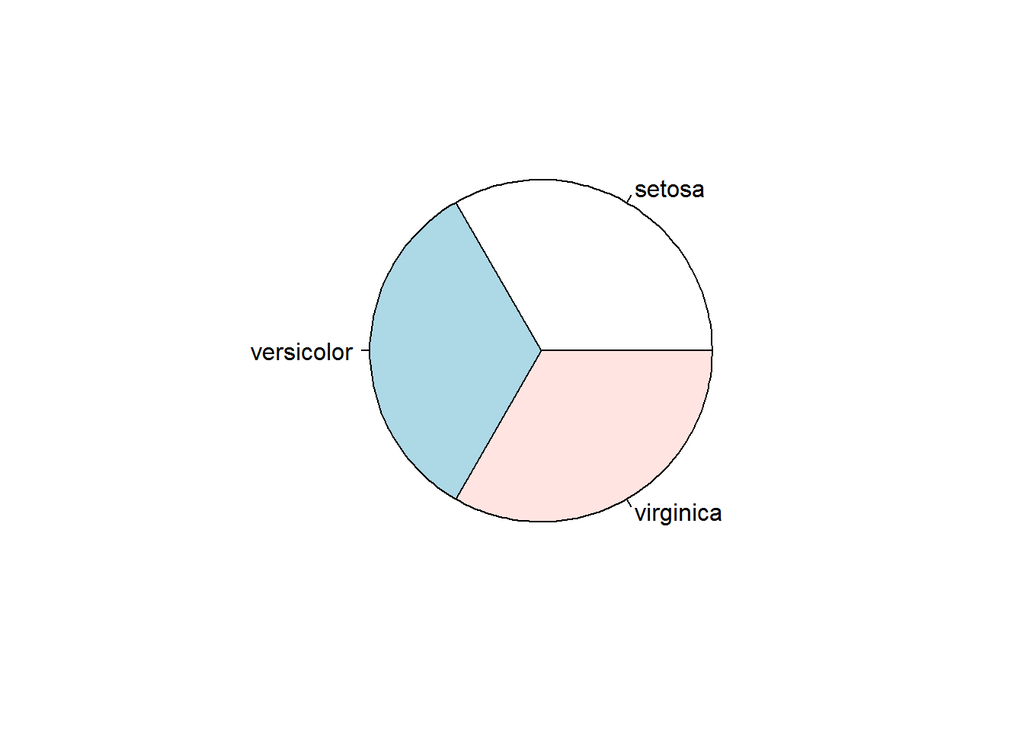

```r
# Graphique
pie(table(iris$Species))
```

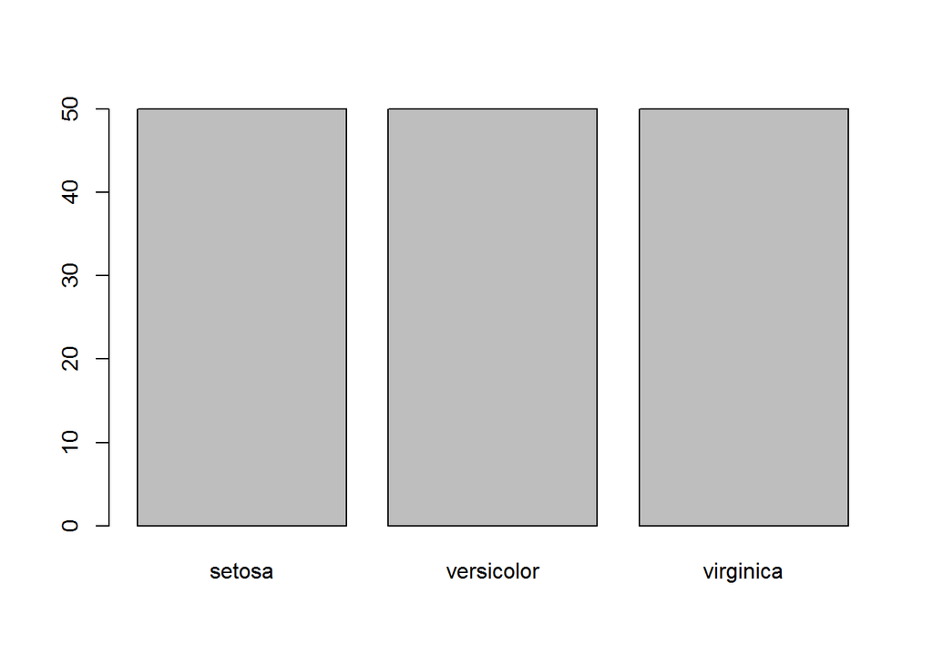

```r
barplot(table(iris$Species))
```

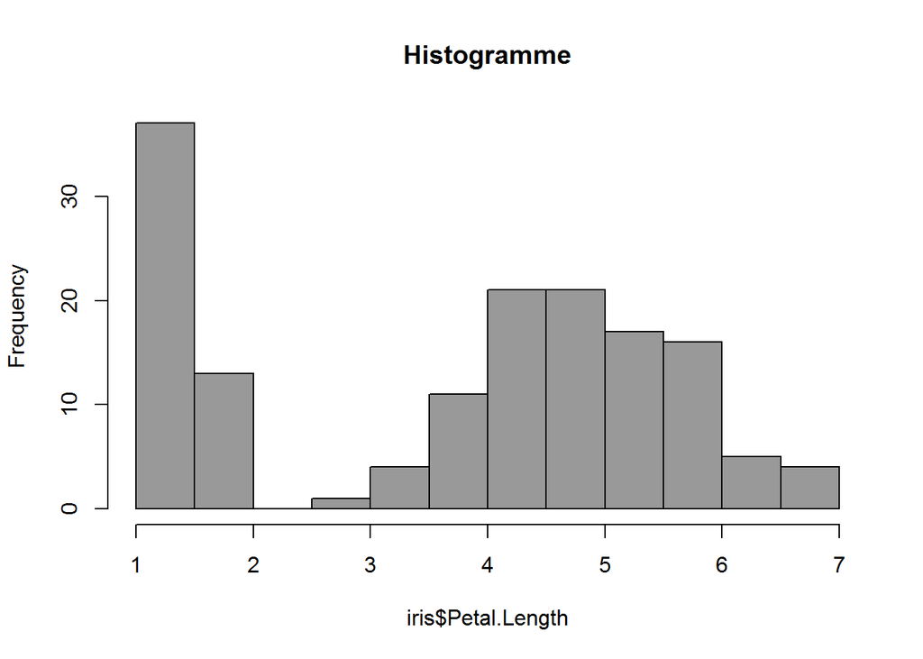

```r
hist(iris$Petal.Length, col = grey(0.6), main = "Histogramme")
```

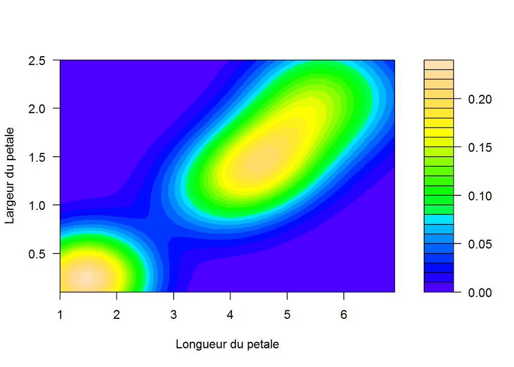

```r
## on peut alors representerla densite des points.
library(MASS)
densite <- kde2d(iris$Petal.Length, iris$Petal.Width)
filled.contour(densite, color = topo.colors, xlab = "Longueur du petale",
ylab = "Largeur du petale")
```

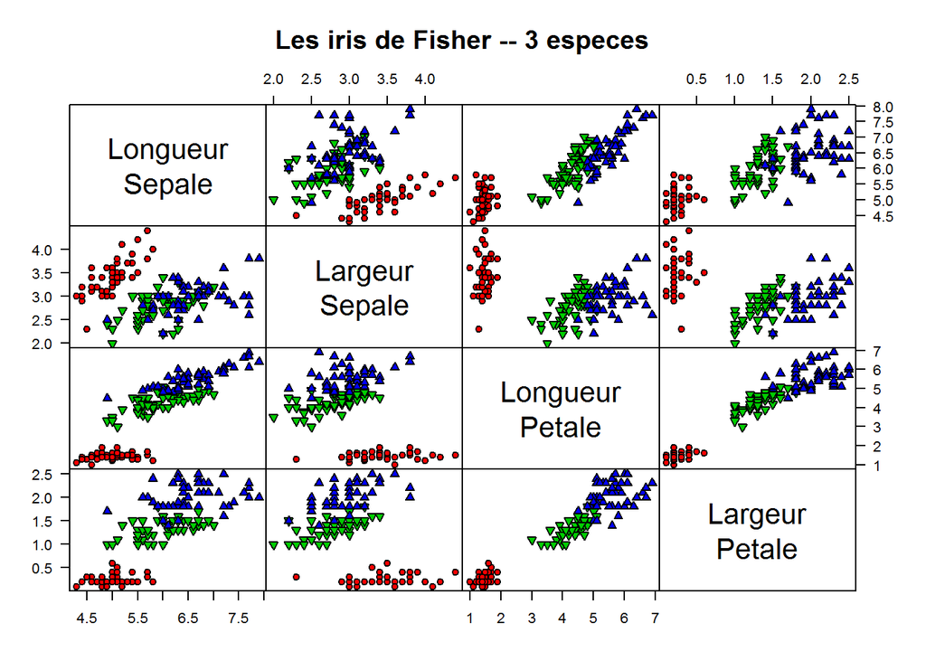

```r
###◘
spiris <- unclass(iris$Species)
pairs(iris[1:4], main = "Les iris de Fisher -- 3 especes", pch = c(21,
25, 24)[spiris], bg = c("red", "green3", "blue")[spiris], las = 1,
gap = 0, labels = c("Longueur\nSepale", "Largeur\nSepale", "Longueur\nPetale",
"Largeur\nPetale"))
```

## Données Old Faithful

Ce jeu de données est accessible dans l’objet R `faithful`, dont la documentation est accessible [ici](https://vincentarelbundock.github.io/Rdatasets/doc/datasets/faithful.html).

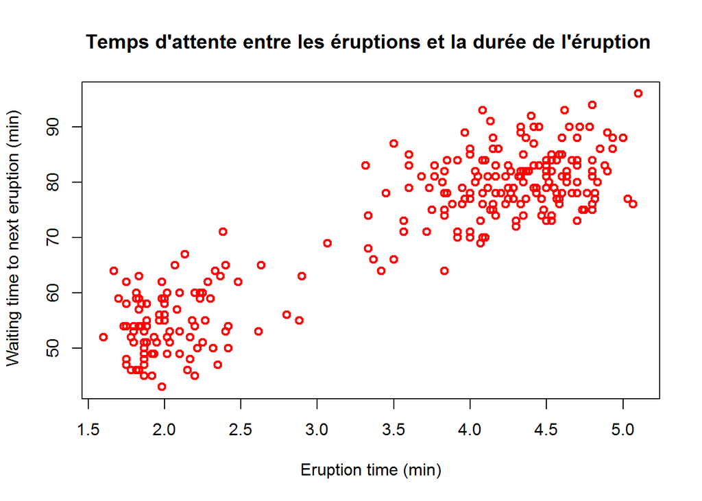

```r
# Analyse descriptive

#Temps d'attente entre les éruptions et la durée de l'éruption du geyser Old #Faithful dans le parc national de Yellowstone


# Graphique

plot(faithful$eruptions , faithful$waiting, type = "p", col = "red", lwd = 2,
     main = "Temps d'attente entre les éruptions et la durée de l'éruption " , ylab = " Waiting time to next eruption (min)" , xlab = "Eruption time (min)" )
```

## Données MTCars

Ce jeu de données est accessible dans l’objet R `mtcars`, dont la documentation est accessible [ici](https://vincentarelbundock.github.io/Rdatasets/doc/datasets/mtcars.html).

```r
# Analyse descriptive
# Graphique
```

## Données EuStockMarkets

Ce jeu de données est accessible dans l’objet R `EuStockMarkets`, dont la documentation est accessible [ici](https://vincentarelbundock.github.io/Rdatasets/doc/datasets/EuStockMarkets.html).

```r
# Analyse descriptive
head(EuStockMarkets)
```

```
##          DAX    SMI    CAC   FTSE
## [1,] 1628.75 1678.1 1772.8 2443.6
## [2,] 1613.63 1688.5 1750.5 2460.2
## [3,] 1606.51 1678.6 1718.0 2448.2
## [4,] 1621.04 1684.1 1708.1 2470.4
## [5,] 1618.16 1686.6 1723.1 2484.7
## [6,] 1610.61 1671.6 1714.3 2466.8
```

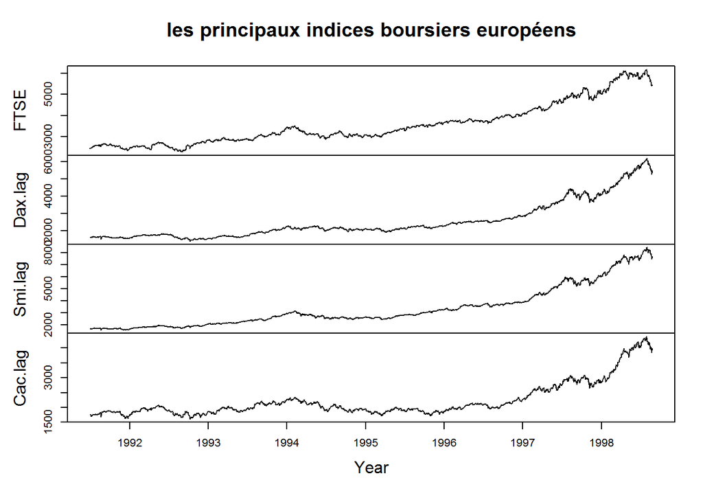

```r
# Graphique
Dax.lag= stats::lag(EuStockMarkets[,"DAX"],-1)
Smi.lag= stats::lag(EuStockMarkets[,"SMI"],-1)
Cac.lag= stats::lag(EuStockMarkets[,"CAC"],-1)

df=cbind(FTSE=EuStockMarkets[,4], Dax.lag, Smi.lag, Cac.lag)
train= window(df, start=c(1991,131), end=c(1997,260))
test=window(df, start=c(1998,1))

plot(df , xlab= "Year"  , main = "les principaux indices boursiers européens")
```

Ce jeu de données accessible sur le net, et téléchargeable de la manière suivante :

```r
bankingCrises = read.csv("https://vincentarelbundock.github.io/Rdatasets/csv/Ecdat/bankingCrises.csv")
```

```r
# Analyse descriptive
# Graphique
```